# TP6

2023-05-08

### Question 1:

```r
dataSAheart <- read.csv("SAheart.csv", header = TRUE)
str(dataSAheart)
```

```
## 'data.frame':    462 obs. of  10 variables:
##  $ sbp      : int  160 144 118 170 134 132 142 114 114 132 ...
##  $ tobacco  : num  12 0.01 0.08 7.5 13.6 6.2 4.05 4.08 0 0 ...
##  $ ldl      : num  5.73 4.41 3.48 6.41 3.5 6.47 3.38 4.59 3.83 5.8 ...
##  $ adiposity: num  23.1 28.6 32.3 38 27.8 ...
##  $ famhist  : chr  "Present" "Absent" "Present" "Present" ...
##  $ typea    : int  49 55 52 51 60 62 59 62 49 69 ...
##  $ obesity  : num  25.3 28.9 29.1 32 26 ...
##  $ alcohol  : num  97.2 2.06 3.81 24.26 57.34 ...
##  $ age      : int  52 63 46 58 49 45 38 58 29 53 ...
##  $ chd      : int  1 1 0 1 1 0 0 1 0 1 ...
```

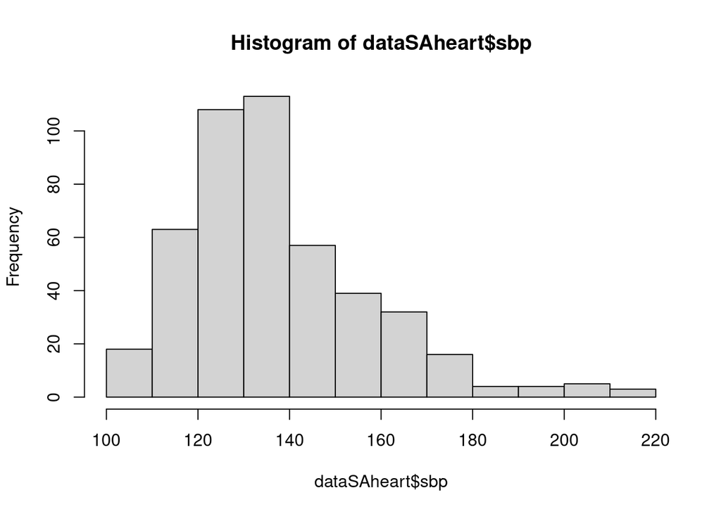

```r
hist(dataSAheart$sbp)
```

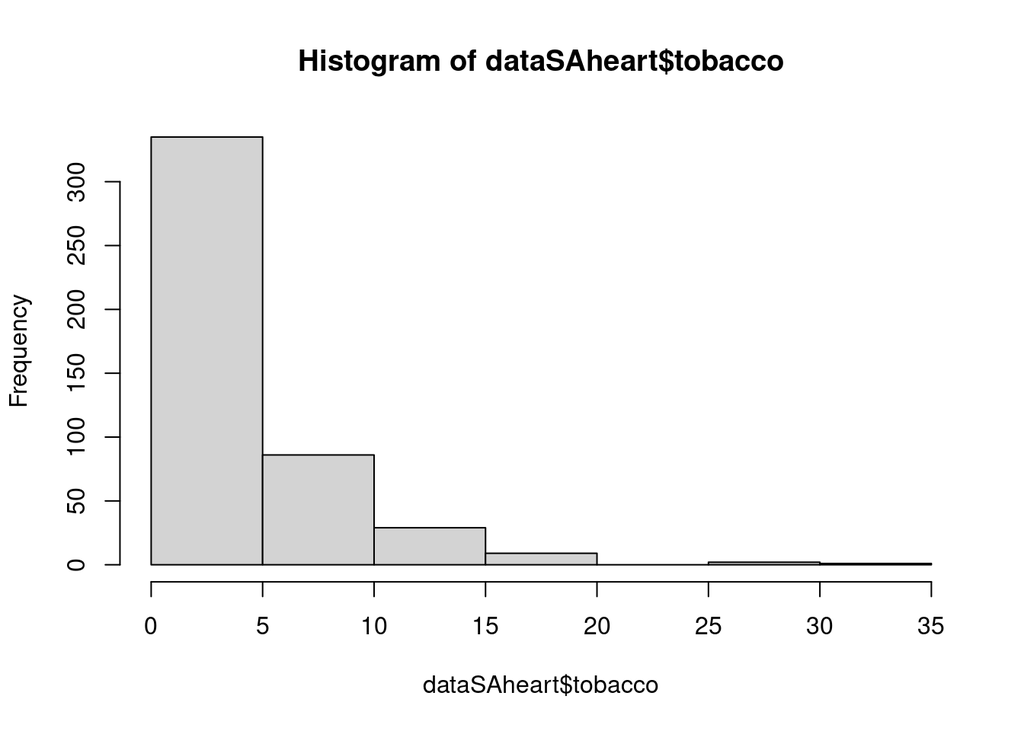

```r
hist(dataSAheart$tobacco)
```

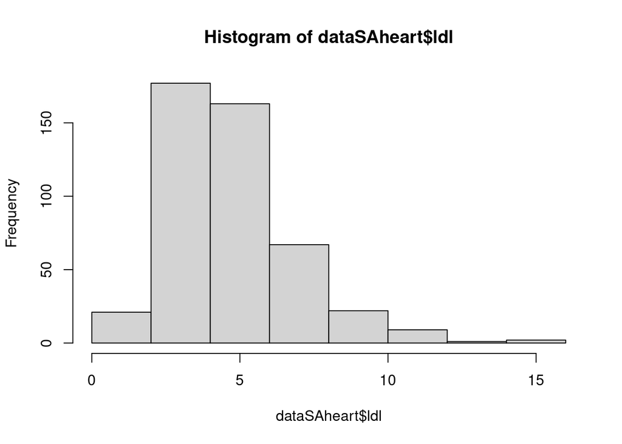

```r
hist(dataSAheart$ldl)
```

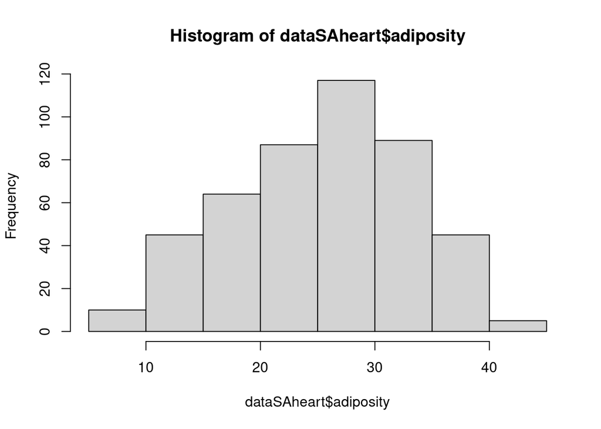

```r
hist(dataSAheart$adiposity)
```

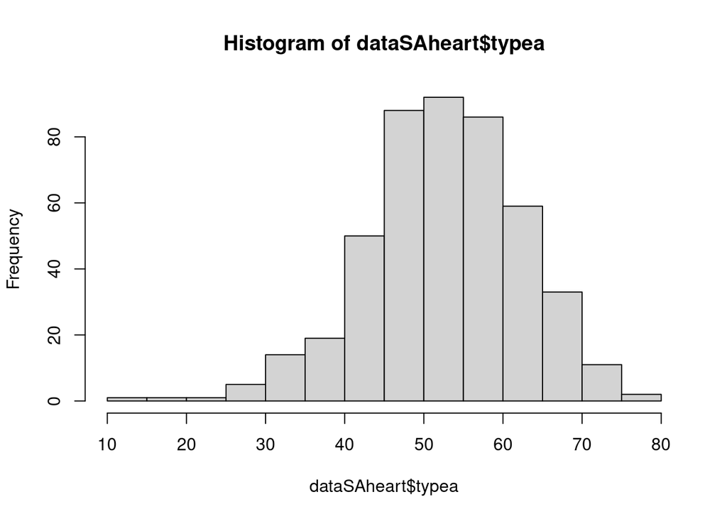

```r
hist(dataSAheart$typea)
```

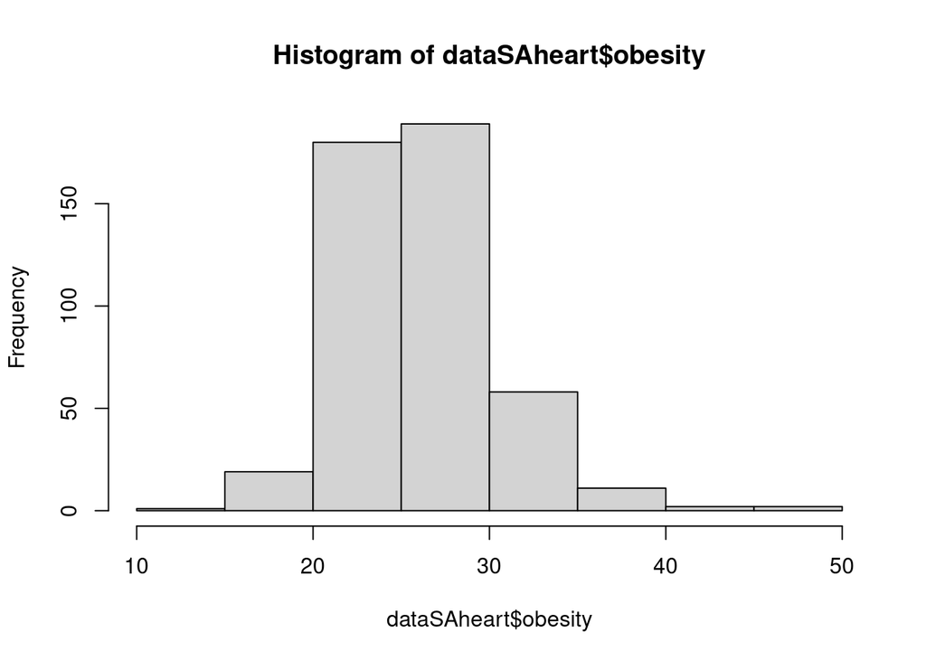

```r
hist(dataSAheart$obesity)
```

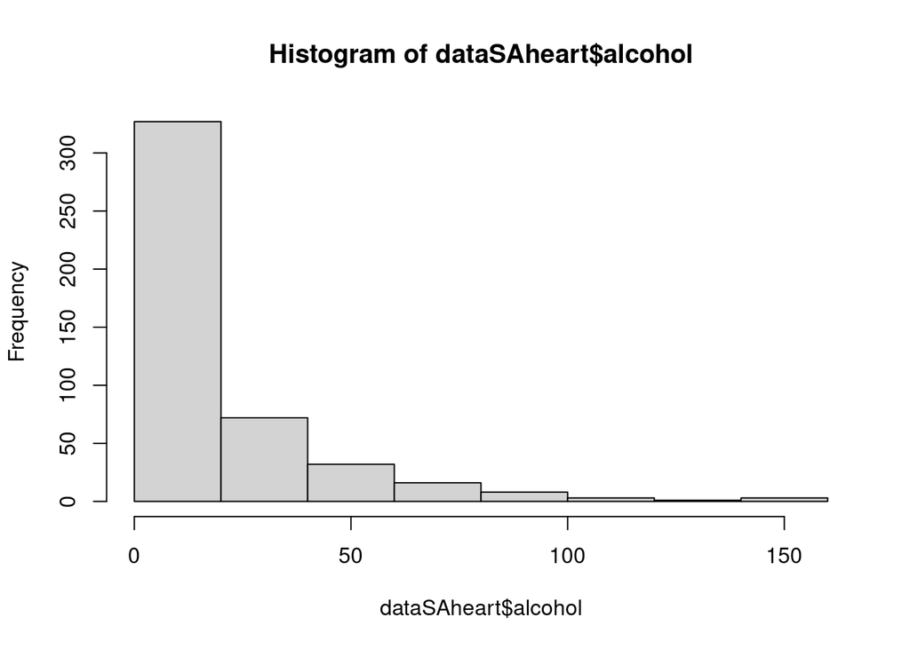

```r
hist(dataSAheart$alcohol)
```

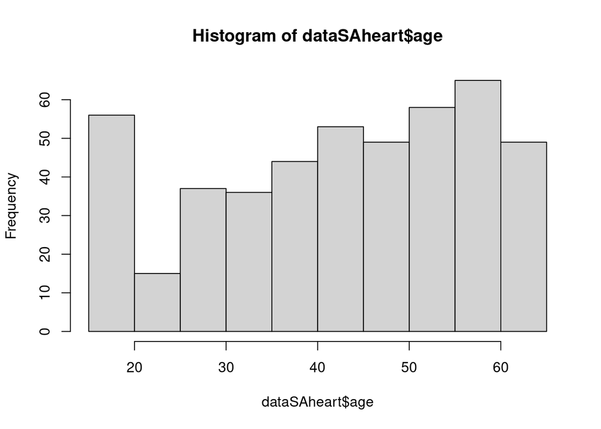

```r
hist(dataSAheart$age)
```

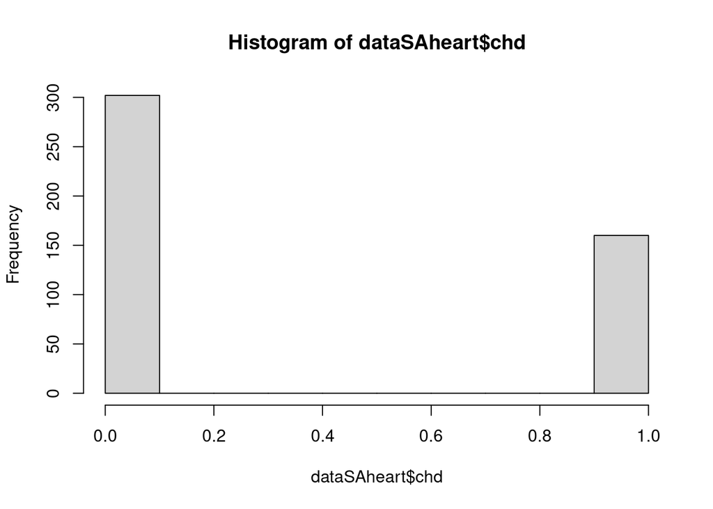

```r
hist(dataSAheart$chd)
```

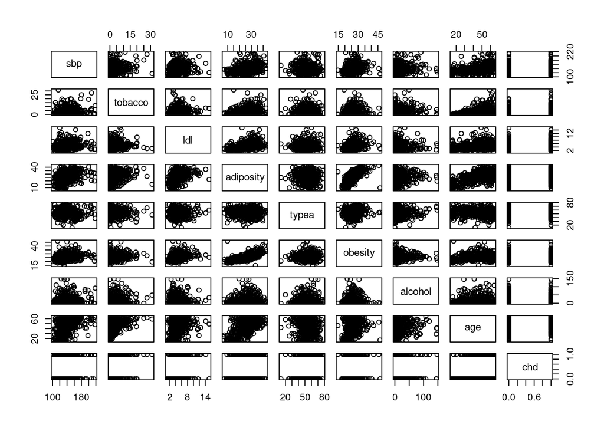

```r
pairs(dataSAheart[ , colnames(dataSAheart) != "famhist"])
```

```r
testSAheart <- dataSAheart[(nrow(dataSAheart)-9):nrow(dataSAheart),]
```

#### Question 2:

```r
fit_model <- glm(chd ~ sbp + tobacco + ldl + adiposity + famhist + typea + obesity + alcohol + age, data = dataSAheart, family = binomial(link = "logit"))
summary(fit_model)
```

```
##
## Call:
## glm(formula = chd ~ sbp + tobacco + ldl + adiposity + famhist +
##     typea + obesity + alcohol + age, family = binomial(link = "logit"),
##     data = dataSAheart)
##
## Deviance Residuals:
##     Min       1Q   Median       3Q      Max
## -1.7781  -0.8213  -0.4387   0.8889   2.5435
##
## Coefficients:
##                  Estimate Std. Error z value Pr(>|z|)
## (Intercept)    -6.1507209  1.3082600  -4.701 2.58e-06 ***
## sbp             0.0065040  0.0057304   1.135 0.256374
## tobacco         0.0793764  0.0266028   2.984 0.002847 **
## ldl             0.1739239  0.0596617   2.915 0.003555 **
## adiposity       0.0185866  0.0292894   0.635 0.525700
## famhistPresent  0.9253704  0.2278940   4.061 4.90e-05 ***
## typea           0.0395950  0.0123202   3.214 0.001310 **
## obesity        -0.0629099  0.0442477  -1.422 0.155095
## alcohol         0.0001217  0.0044832   0.027 0.978350
## age             0.0452253  0.0121298   3.728 0.000193 ***
## ---
## Signif. codes:  0 '***' 0.001 '**' 0.01 '*' 0.05 '.' 0.1 ' ' 1
##
## (Dispersion parameter for binomial family taken to be 1)
##
##     Null deviance: 596.11  on 461  degrees of freedom
## Residual deviance: 472.14  on 452  degrees of freedom
## AIC: 492.14
##
## Number of Fisher Scoring iterations: 5
```

```r
confint(fit_model)
```

```
##                       2.5 %       97.5 %
## (Intercept)    -8.776310263 -3.635601450
## sbp            -0.004679441  0.017869495
## tobacco         0.028502582  0.133172468
## ldl             0.059195093  0.293942936
## adiposity      -0.038421788  0.076703238
## famhistPresent  0.481064463  1.375753784
## typea           0.015873307  0.064277041
## obesity        -0.152266153  0.021857760
## alcohol        -0.008790100  0.008906874
## age             0.021718337  0.069386258
```

### Question 3:

```r
library(MASS)
# Perform backward variable selection using stepAIC()
step.model <- stepAIC(fit_model, direction = "backward")
```

```
## Start:  AIC=492.14
## chd ~ sbp + tobacco + ldl + adiposity + famhist + typea + obesity +
##     alcohol + age
##
##             Df Deviance    AIC
## - alcohol    1   472.14 490.14
## - adiposity  1   472.55 490.55
## - sbp        1   473.44 491.44
## <none>           472.14 492.14
## - obesity    1   474.23 492.23
## - ldl        1   481.07 499.07
## - tobacco    1   481.67 499.67
## - typea      1   483.05 501.05
## - age        1   486.53 504.53
## - famhist    1   488.89 506.89
##
## Step:  AIC=490.14
## chd ~ sbp + tobacco + ldl + adiposity + famhist + typea + obesity +
##     age
##
##             Df Deviance    AIC
## - adiposity  1   472.55 488.55
## - sbp        1   473.47 489.47
## <none>           472.14 490.14
## - obesity    1   474.24 490.24
## - ldl        1   481.15 497.15
## - tobacco    1   482.06 498.06
## - typea      1   483.06 499.06
## - age        1   486.64 502.64
## - famhist    1   488.99 504.99
##
## Step:  AIC=488.55
## chd ~ sbp + tobacco + ldl + famhist + typea + obesity + age
##
##           Df Deviance    AIC
## - sbp      1   473.98 487.98
## <none>         472.55 488.55
## - obesity  1   474.65 488.65
## - tobacco  1   482.54 496.54
## - ldl      1   482.95 496.95
```

[output cut: 11 more lines]

```
## - typea    1   484.30 496.30
## - ldl      1   484.53 496.53
## - famhist  1   490.58 502.58
## - age      1   502.11 514.11
##
## Step:  AIC=487.69
## chd ~ tobacco + ldl + famhist + typea + age
##
##           Df Deviance    AIC
## <none>         475.69 487.69
## - ldl      1   484.71 494.71
## - typea    1   485.44 495.44
## - tobacco  1   486.03 496.03
## - famhist  1   492.09 502.09
## - age      1   502.38 512.38
```

```r
summary(step.model)
```

```
##
## Call:
## glm(formula = chd ~ tobacco + ldl + famhist + typea + age, family = binomial(link = "logit"),
##     data = dataSAheart)
##
## Deviance Residuals:
##     Min       1Q   Median       3Q      Max
## -1.9165  -0.8054  -0.4430   0.9329   2.6139
##
## Coefficients:
##                Estimate Std. Error z value Pr(>|z|)
## (Intercept)    -6.44644    0.92087  -7.000 2.55e-12 ***
## tobacco         0.08038    0.02588   3.106  0.00190 **
## ldl             0.16199    0.05497   2.947  0.00321 **
## famhistPresent  0.90818    0.22576   4.023 5.75e-05 ***
## typea           0.03712    0.01217   3.051  0.00228 **
## age             0.05046    0.01021   4.944 7.65e-07 ***
## ---
## Signif. codes:  0 '***' 0.001 '**' 0.01 '*' 0.05 '.' 0.1 ' ' 1
##
## (Dispersion parameter for binomial family taken to be 1)
##
##     Null deviance: 596.11  on 461  degrees of freedom
## Residual deviance: 475.69  on 456  degrees of freedom
## AIC: 487.69
##
## Number of Fisher Scoring iterations: 5
```

les AIC backward a sélectionné les prédicteurs : tabacco, ldl, famhist, typea, age . ce qui montre l’analyse fait précedent . en réalité on que: Le coefficient positif de famhist et son importance dans le modèle indique que les personnes ayant des antécédents familiaux de maladies cardiaques ont une probabilité plus élevée d’être atteints de maladies cardiaques que celles qui n’ont pas d’antécédents familiaux. L’estimation du coefficient pour famhist est de 0.9253704, ce qui signifie que les personnes ayant des antécédents familiaux de maladie cardiaque ont approx e^0.9253704 fois plus de chances d’être atteintes de maladies cardiaques que celles qui n’ont pas d’antécédents familiaux, toutes les autres variables étant constantes.

Et pour pour l’âge ça suggère qu’à mesure que l’âge augmente, le logarithme de la probabilité d’être atteint d’une maladie coronarienne augmente également. Ce qui signifie que, pour chaque année d’augmentation de l’âge, le logarithme des chances d’être atteint de la maladie augmente, toutes les autres variables étant constantes.

Les coefficients des autres prédicteurs (sbp, adiposité, obésité et alcool) ne sont pas statistiquement significatifs au niveau de 0,05, ce qui signifie qu’il n’y a pas suffisamment de preuves pour conclure que ces prédicteurs sont associés à la probabilité d’avoir un chd, toutes les autres variables restant constantes.

### Question 4:

```r
library(MASS)

# Fit the constant model
const.model <- glm(chd ~ 1, data = dataSAheart, family = "binomial")

# Perform forward variable selection using stepAIC()
backward.model <- stepAIC(const.model, direction = "forward", scope = formula(~ sbp + tobacco + ldl + adiposity + famhist + typea + obesity + alcohol + age), data = dataSAheart)
```

```
## Start:  AIC=598.11
## chd ~ 1
##
##             Df Deviance    AIC
## + age        1   525.56 529.56
## + tobacco    1   554.65 558.65
## + famhist    1   561.89 565.89
## + ldl        1   564.28 568.28
## + adiposity  1   565.05 569.05
## + sbp        1   579.32 583.32
## + typea      1   591.12 595.12
## + obesity    1   591.53 595.53
## <none>           596.11 598.11
## + alcohol    1   594.35 598.35
##
## Step:  AIC=529.56
## chd ~ age
##
##             Df Deviance    AIC
## + famhist    1   506.66 512.66
## + ldl        1   512.48 518.48
## + typea      1   513.04 519.04
## + tobacco    1   515.39 521.39
## <none>           525.56 529.56
## + sbp        1   524.44 530.44
## + adiposity  1   524.78 530.78
## + alcohol    1   524.89 530.89
## + obesity    1   525.55 531.55
##
## Step:  AIC=512.66
## chd ~ age + famhist
##
##             Df Deviance    AIC
## + tobacco    1   495.39 503.39
## + typea      1   495.64 503.64
## + ldl        1   496.18 504.18
## <none>           506.66 512.66
## + sbp        1   505.24 513.24
## + adiposity  1   506.22 514.22
## + alcohol    1   506.29 514.29
```

[output cut: 19 more lines]

```
## <none>           484.71 494.71
## + sbp        1   483.31 495.31
## + adiposity  1   484.37 496.37
## + obesity    1   484.53 496.53
## + alcohol    1   484.70 496.70
##
## Step:  AIC=487.69
## chd ~ age + famhist + tobacco + typea + ldl
##
##             Df Deviance    AIC
## <none>           475.69 487.69
## + obesity    1   473.98 487.98
## + sbp        1   474.65 488.65
## + adiposity  1   475.44 489.44
## + alcohol    1   475.65 489.65
```

```r
summary(backward.model)
```

```
##
## Call:
## glm(formula = chd ~ age + famhist + tobacco + typea + ldl, family = "binomial",
##     data = dataSAheart)
##
## Deviance Residuals:
##     Min       1Q   Median       3Q      Max
## -1.9165  -0.8054  -0.4430   0.9329   2.6139
##
## Coefficients:
##                Estimate Std. Error z value Pr(>|z|)
## (Intercept)    -6.44644    0.92087  -7.000 2.55e-12 ***
## age             0.05046    0.01021   4.944 7.65e-07 ***
## famhistPresent  0.90818    0.22576   4.023 5.75e-05 ***
## tobacco         0.08038    0.02588   3.106  0.00190 **
## typea           0.03712    0.01217   3.051  0.00228 **
## ldl             0.16199    0.05497   2.947  0.00321 **
## ---
## Signif. codes:  0 '***' 0.001 '**' 0.01 '*' 0.05 '.' 0.1 ' ' 1
##
## (Dispersion parameter for binomial family taken to be 1)
##
##     Null deviance: 596.11  on 461  degrees of freedom
## Residual deviance: 475.69  on 456  degrees of freedom
## AIC: 487.69
##
## Number of Fisher Scoring iterations: 5
```

```r
AIC(step.model)
```

```
## [1] 487.6856
```

```r
AIC(backward.model)
```

```
## [1] 487.6856
```

Les prédicteurs sélectionnés par AIC forward sont : age , famhist , tobacco , typea et ldl sont celles choisi par AIC backward . donc malgré le critére d’évaluation différent de AIC forward et AIC backward on a trouvé les mêmes variables sélectionnées. Ce qui signifie la forte chance que les variables éliminées ne soient pas statistiquement siginificatifs.

### Question 5:

```r
# Predict the probability of CHD on the test data
testSAheart[ , colnames(testSAheart) == "chd"]
```

```
##  [1] 0 1 1 1 0 0 1 0 0 1
```

```r
chd_prob <- predict(fit_model, newdata = testSAheart, type = "response")
chd_prob
```

```
##        453        454        455        456        457        458        459
## 0.49553249 0.36624694 0.19479807 0.07337728 0.53040285 0.56706500 0.34143862
##        460        461        462
## 0.13705505 0.56521383 0.66884212
```

### Question 6:

Linear discriminant analysis (LDA) est une méthode de classification qui permet de trouver une combinaison linéaire de variables prédictives séparant au mieux les classes d’un ensemble de données donné. Dans le cas présent, nous pouvons utiliser l’analyse discriminante linéaire pour classer les individus comme atteints ou non d’une maladie coronarienne en fonction de leurs valeurs pour les variables prédictives.

Nous pouvons utiliser la fonction predict() pour classer de nouvelles données sur la base du modèle LDA. La fonction predict() renvoie une liste à deux composantes : class et posterior. La composante classe contient les étiquettes de classe prédites (0 pour pas de coronaropathie, 1 pour coronaropathie) et la composante postérieure contient les probabilités prédites de chaque classe.

```r
library(MASS)

# Fit the LDA model
lda.model <- lda(chd ~ sbp + tobacco + ldl + adiposity + famhist + typea + obesity + alcohol + age, data = dataSAheart)

# Predict the CHD status on the last 10 rows
lda.pred <- predict(lda.model, newdata = tail(dataSAheart, 10))

# Print the predicted CHD status and probabilities
lda.pred$class
```

```
##  [1] 0 0 0 0 1 1 0 0 1 1
## Levels: 0 1
```

```r
lda.pred$posterior
```

```
##             0          1
## 453 0.5013918 0.49860817
## 454 0.6239995 0.37600047
## 455 0.8124126 0.18758739
## 456 0.9263298 0.07367017
## 457 0.4995422 0.50045780
## 458 0.4541331 0.54586689
## 459 0.6652965 0.33470349
## 460 0.8697687 0.13023133
## 461 0.4222696 0.57773036
## 462 0.3419692 0.65803080
```

Pour comparer les résultats de LDA avec le modèle de régression logistique que nous avons ajusté précédemment, nous pouvons utiliser des mesures telles que l’exactitude, la précision, le rappel et le score F1. Nous pouvons également examiner la matrice de confusion pour connaître le nombre de vrais positifs, de vrais négatifs, de faux positifs et de faux négatifs, on voit que les deux modèles ont presque la même probabilité de prédiction.

Cependant, il est important de noter que la méthode LDA suppose que les prédicteurs ont une distribution normale multivariée dans chaque classe et que les matrices de covariance sont égales entre les classes. Ces hypothèses peuvent ne pas se vérifier dans la pratique et affecter la précision et la fiabilité des résultats de la classification. C’est pourquoi il est toujours bon d’évaluer les hypothèses et les limites de la méthode de classification avant de tirer des conclusions ou de prendre des décisions sur la base des résultats.